# Biostat 212a Homework 6

Due Mar 22, 2025 @ 11:59PM

Author

Molly Shi (UID: 906558988)

Published

March 22, 2025

> Note: Since the cross validation takes a long time to train on my local machine, I set the `eval` parameter to `FALSE` for the cross validation code chunks. For the complete results for the cross validation, please refer to my [Colab Notebook](https://colab.research.google.com/drive/1PbrqAw7BuEzy9_mFwUXNd-5XFE8Ozl9T?usp=sharing).

Load R libraries.

```r
library(tidyverse)
library(tidymodels)
library(readr)
library(tswge)
library(ggplot2)
library(ranger)
library(umap)

acfdf <- function(vec) {
    vacf <- acf(vec, plot = F)
    with(vacf, data.frame(lag, acf))
}

ggacf <- function(vec) {
    ac <- acfdf(vec)
    ggplot(data = ac, aes(x = lag, y = acf)) + geom_hline(aes(yintercept = 0)) +
        geom_segment(mapping = aes(xend = lag, yend = 0))
}

tplot <- function(vec) {
    df <- data.frame(X = vec, t = seq_along(vec))
    ggplot(data = df, aes(x = t, y = X)) + geom_line()
}
```

## 1 New York Stock Exchange (NYSE) data (1962-1986) (140 pts)

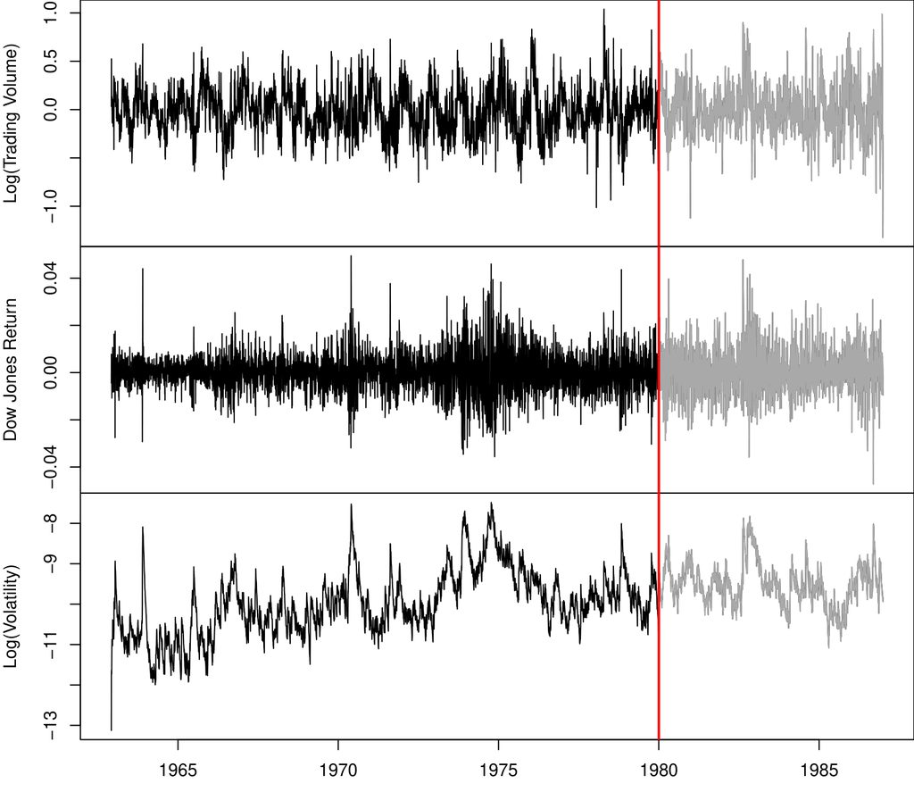

Figure 1: Historical trading statistics from the New York Stock Exchange. Daily values of the normalized log trading volume, DJIA return, and log volatility are shown for a 24-year period from 1962-1986. We wish to predict trading volume on any day, given the history on all earlier days. To the left of the red bar (January 2, 1980) is training data, and to the right test data.

The [`NYSE.csv`](https://raw.githubusercontent.com/ucla-biostat-212a/2025winter/master/slides/data/NYSE.csv) file contains three daily time series from the New York Stock Exchange (NYSE) for the period Dec 3, 1962-Dec 31, 1986 (6,051 trading days).

- `Log trading volume` ($v_t$): This is the fraction of all outstanding shares that are traded on that day, relative to a 100-day moving average of past turnover, on the log scale.
- `Dow Jones return` ($r_t$): This is the difference between the log of the Dow Jones Industrial Index on consecutive trading days.
- `Log volatility` ($z_t$): This is based on the absolute values of daily price movements.

```r
# Read in NYSE data from url

url = "https://raw.githubusercontent.com/ucla-biostat-212a/2025winter/master/slides/data/NYSE.csv"
NYSE <- read_csv(url)

NYSE
```

```
# A tibble: 6,051 × 6
   date       day_of_week DJ_return log_volume log_volatility train
   <date>     <chr>           <dbl>      <dbl>          <dbl> <lgl>
 1 1962-12-03 mon         -0.00446     0.0326           -13.1 TRUE
 2 1962-12-04 tues         0.00781     0.346            -11.7 TRUE
 3 1962-12-05 wed          0.00384     0.525            -11.7 TRUE
 4 1962-12-06 thur        -0.00346     0.210            -11.6 TRUE
 5 1962-12-07 fri          0.000568    0.0442           -11.7 TRUE
 6 1962-12-10 mon         -0.0108      0.133            -10.9 TRUE
 7 1962-12-11 tues         0.000124   -0.0115           -11.0 TRUE
 8 1962-12-12 wed          0.00336     0.00161          -11.0 TRUE
 9 1962-12-13 thur        -0.00330    -0.106            -11.0 TRUE
10 1962-12-14 fri          0.00447    -0.138            -11.0 TRUE
# ℹ 6,041 more rows
```

The **autocorrelation** at lag $\ell$ is the correlation of all pairs $(v_t, v_{t-\ell})$ that are $\ell$ trading days apart. These sizable correlations give us confidence that past values will be helpful in predicting the future.

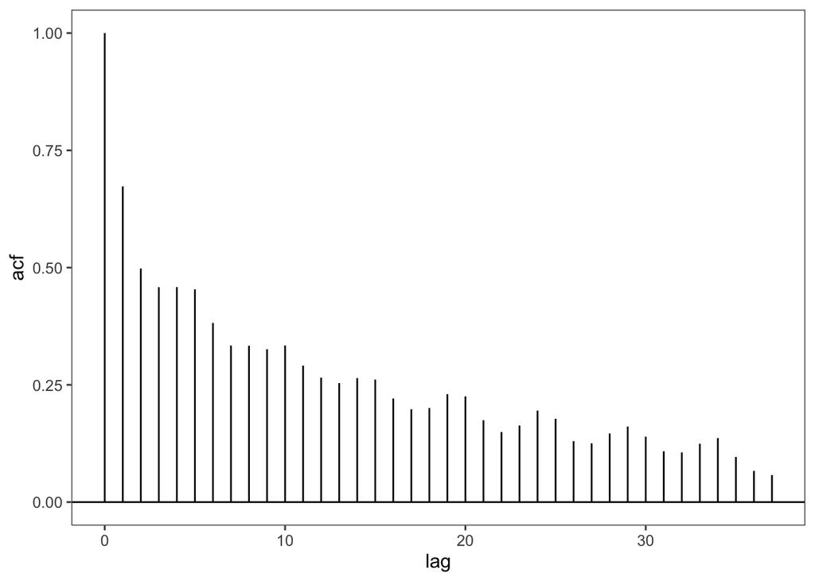

Figure 2: The autocorrelation function for log volume. We see that nearby values are fairly strongly correlated, with correlations above 0.2 as far as 20 days apart.

```r
ggacf(NYSE$log_volume) + ggthemes::theme_few()
```

Do a similar plot for (1) the correlation between $v_t$ and lag $\ell$ `Dow Jones return` $r_{t-\ell}$ and (2) correlation between $v_t$ and lag $\ell$ `Log volatility` $z_{t-\ell}$.

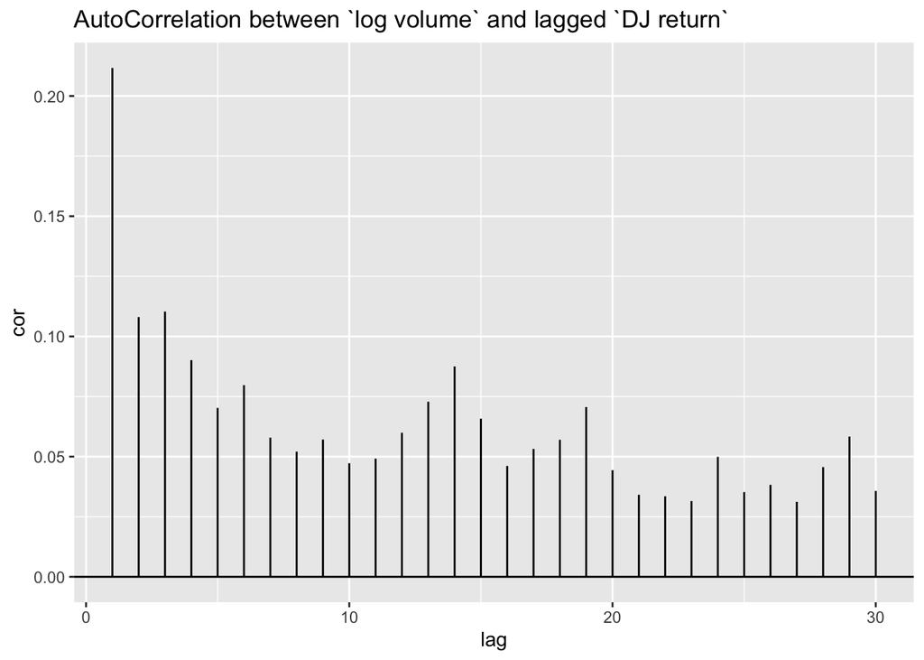

```r
seq(1, 30) %>%
  map(function(x) {cor(NYSE$log_volume , lag(NYSE$DJ_return, x), use = "pairwise.complete.obs")}) %>%
  unlist() %>%
  tibble(lag = 1:30, cor = .) %>%
  ggplot(aes(x = lag, y = cor)) +
  geom_hline(aes(yintercept = 0)) +
  geom_segment(mapping = aes(xend = lag, yend = 0)) +
  ggtitle("AutoCorrelation between `log volume` and lagged `DJ return`")
```

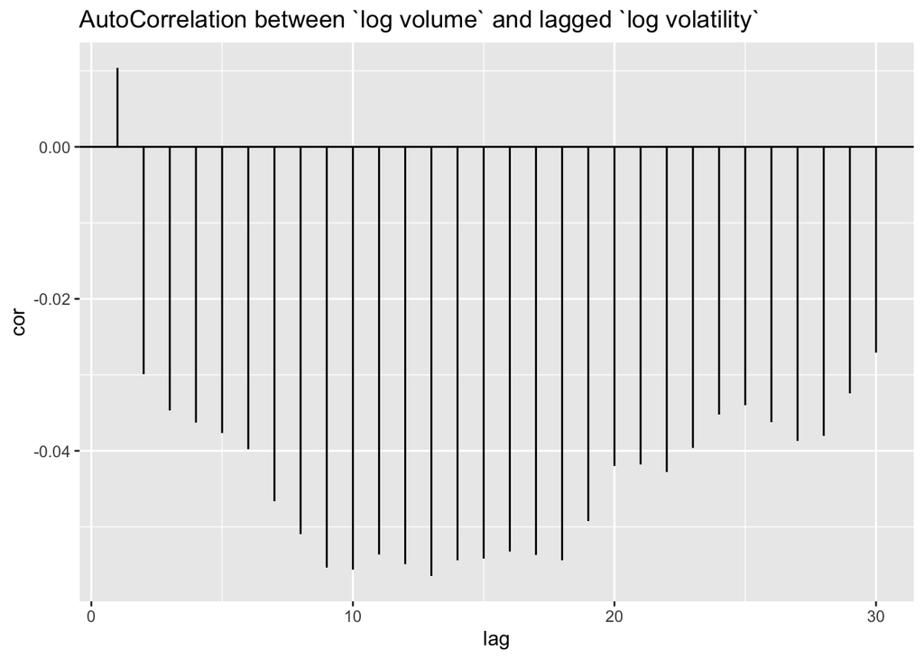

```r
seq(1, 30) %>%
  map(function(x) {cor(NYSE$log_volume , lag(NYSE$log_volatility, x), use = "pairwise.complete.obs")}) %>%
  unlist() %>%
  tibble(lag = 1:30, cor = .) %>%
  ggplot(aes(x = lag, y = cor)) +
  geom_hline(aes(yintercept = 0)) +
  geom_segment(mapping = aes(xend = lag, yend = 0)) +
  ggtitle("AutoCorrelation between `log volume` and lagged `log volatility`")
```

### 1.1 Project goal

Our goal is to forecast daily `Log trading volume`, using various machine learning algorithms we learnt in this class.

The data set is already split into train (before Jan 1st, 1980, $n_{\text{train}} = 4,281$) and test (after Jan 1st, 1980, $n_{\text{test}} = 1,770$) sets.

In general, we will tune the lag $L$ to acheive best forecasting performance. In this project, we would fix $L=5$. That is we always use the previous five trading days’ data to forecast today’s `log trading volume`.

Pay attention to the nuance of splitting time series data for cross validation. Study and use the [`time-series`](https://www.tidymodels.org/learn/models/time-series/) functionality in tidymodels. Make sure to use the same splits when tuning different machine learning algorithms.

Use the $R^2$ between forecast and actual values as the cross validation and test evaluation criterion.

```r
# ================================
# Data Preparation
# ================================
NYSE <- NYSE |>
  mutate(
    lag_log_volume_1 = lag(log_volume, 1),
    lag_log_volume_2 = lag(log_volume, 2),
    lag_log_volume_3 = lag(log_volume, 3),
    lag_log_volume_4 = lag(log_volume, 4),
    lag_log_volume_5 = lag(log_volume, 5)
  )

train_set <- NYSE |> filter(train == TRUE) |> drop_na()
test_set <- NYSE |> filter(train == FALSE) |> drop_na()
```

```r
# ================================
# Evaluation Metric -- R^2
# ================================
r_squared <- function(actual, predicted) {
  ss_res <- sum((actual - predicted)^2)
  ss_tot <- sum((actual - mean(actual))^2)
  1 - (ss_res / ss_tot)
}
```

### 1.2 Baseline method (20 pts)

We use the straw man (use yesterday’s value of `log trading volume` to predict that of today) as the baseline method. Evaluate the $R^2$ of this method on the test data.

```r
# ================================
# Baseline -- Straw-man Model
# ================================
baseline_pred <- NYSE |>
  mutate(log_volume_pred = lag(log_volume)) |>
  filter(train == FALSE)

# Compute R^2 for baseline
baseline_r2 <- r_squared(baseline_pred$log_volume,
                         baseline_pred$log_volume_pred)

cat("Baseline R^2:", baseline_r2)
```

```
Baseline R^2: 0.1802629
```

### 1.3 Autoregression (AR) forecaster (30 pts)

- Let
  $$y = \begin{pmatrix} v_{L+1} \\ v_{L+2} \\ v_{L+3} \\ \vdots \\ v_T \end{pmatrix}, \quad M = \begin{pmatrix}
  1 & v_L & v_{L-1} & \cdots & v_1 \\
  1 & v_{L+1} & v_{L} & \cdots & v_2 \\
  \vdots & \vdots & \vdots & \ddots & \vdots \\
  1 & v_{T-1} & v_{T-2} & \cdots & v_{T-L}
  \end{pmatrix}.$$
- Fit an ordinary least squares (OLS) regression of $y$ on $M$, giving
  $$\hat v_t = \hat \beta_0 + \hat \beta_1 v_{t-1} + \hat \beta_2 v_{t-2} + \cdots + \hat \beta_L v_{t-L},$$
  known as an **order-**$L$ autoregression model or **AR(**$L$).
- Tune AR(5) with elastic net (lasso + ridge) regularization using all 3 features on the training data, and evaluate the test performance.
- Hint: [Workflow: Lasso](https://ucla-biostat-212a.github.io/2025winter/slides/06-modelselection/workflow_lasso.html) is a good starting point.

```r
# ================================
# AR Forecaster Model
# ================================
set.seed(42)
# Define recipe
ar5_recipe <- recipe(log_volume ~ ., data = train_set) |>
  update_role(date, new_role = "ID") |>
  step_integer(day_of_week, -all_outcomes()) |>
  step_zv(all_predictors()) |>
  step_normalize(all_predictors())

# Define model (Elastic Net with tuning)
lasso_mod <- linear_reg(penalty = tune(), mixture = 1.0) |>
  set_engine("glmnet")

# Define workflow
ar5_lasso_workflow <- workflow() |>
  add_model(lasso_mod) |>
  add_recipe(ar5_recipe)
```

```r
# ================================
# AR Forecaster CV
# ================================
# Cross-validation setup for time series
cv_folds <- rolling_origin(train_set,
                           initial = as.integer(0.8 * nrow(train_set)),
                           assess = as.integer(0.2 * nrow(train_set) / 5),
                           skip = as.integer(0.2 * nrow(train_set) / 5),
                           cumulative = TRUE)

# Define tuning grid
lambda_grid <- grid_regular(penalty(range = c(-2, 1.5),
                                    trans = log10_trans()),
                            levels = 50)

# Tune hyperparameters
tune_results <- tune_grid(
  ar5_lasso_workflow,
  resamples = cv_folds,
  grid = lambda_grid,
  metrics = metric_set(rsq),
  control = control_grid(save_pred = TRUE, verbose = TRUE)  # Verbose mode
)

# Get the best parameter
best_params <- select_best(tune_results, metric = "rsq")
print(best_params)

# Get the CV metric
ar5_cv_metrics <- collect_metrics(tune_results) |>
  slice_max(mean, n = 1)
cat("\n", "AR(5) Elastic Net CV R^2:", ar5_cv_metrics$mean)
```

```r
# ================================
# AR Forecaster Evaluation
# ================================
# Build a new model using tuned parameter penalty = 0.01
lasso_mod_final <- linear_reg(penalty = 0.01, mixture = 1.0) |>
  set_engine("glmnet")

# Define workflow with the final model
ar5_lasso_final_workflow <- workflow() |>
  add_model(lasso_mod_final) |>
  add_recipe(ar5_recipe)

# Fit the final model on the training data
lasso_final_fit <- fit(ar5_lasso_final_workflow, data = train_set)

# Predict on test set
test_preds <- predict(lasso_final_fit, new_data = test_set) |>
  bind_cols(test_set)

# Compute R^2 for the final model on the test set
lasso_ar5_r2 <- r_squared(test_preds$log_volume, test_preds$.pred)
cat("AR(5) Elastic Net Test R^2:", lasso_ar5_r2, "\n")
```

```
AR(5) Elastic Net Test R^2: 0.4322716
```

### 1.4 Random forest forecaster (30pts)

- Use the same features as in AR($L$) for the random forest. Tune the random forest and evaluate the test performance.
- Hint: [Workflow: Random Forest for Prediction](https://ucla-biostat-212a.github.io/2025winter/slides/08-tree/workflow_rf_reg.html) is a good starting point.

```r
# ================================
# Random Forest Forecaster Model
# ================================
# Define recipe
rf_recipe <- recipe(log_volume ~ ., data = train_set) |>
  update_role(date, new_role = "ID") |>
  step_zv(all_predictors())

# Define model (Random Forest with tuning)
rf_mod <- rand_forest(mtry = tune(), trees = tune()) |>
  set_engine("ranger") |>
  set_mode("regression")

# Define workflow
rf_workflow <- workflow() |>
  add_model(rf_mod) |>
  add_recipe(rf_recipe)
```

```r
# ================================
# Random Forest Forecaster CV
# ================================
# Cross-validation setup for time series
set.seed(42)
cv_folds <- rolling_origin(train_set,
                           initial = as.integer(0.8 * nrow(train_set)),
                           assess = as.integer(0.2 * nrow(train_set) / 5),
                           skip = as.integer(0.2 * nrow(train_set) / 5),
                           cumulative = TRUE)

# Define tuning grid
rf_grid <- grid_regular(
  trees(range = c(500, 800)),
  mtry(range = c(4, 6)),
  levels = 4
)
# Tune hyperparameters
rf_tune_results <- tune_grid(
  rf_workflow,
  resamples = cv_folds,
  grid = rf_grid,
  metrics = metric_set(rsq),
  control = control_grid(save_pred = TRUE, verbose = TRUE)  # Verbose mode
)

# Get the best parameters
best_rf_params <- select_best(rf_tune_results, metric = "rsq")
print(best_rf_params)

# Get the CV metric
rf_cv_metrics <- collect_metrics(rf_tune_results) |>
  slice_max(mean, n = 1)
cat("\n", "Random Forest CV R^2:", rf_cv_metrics$mean)
```

```r
# ================================
# Random Forest Forecaster Evaluation
# ================================
set.seed(42)
# Define final model with best parameters
rf_mod_final <- rand_forest(
  trees = 800,
  mtry = 4
) |>
  set_engine("ranger") |>
  set_mode("regression")

# Define workflow with the final model
rf_final_workflow <- workflow() |>
  add_model(rf_mod_final) |>
  add_recipe(rf_recipe)

# Fit the final model on the training data
rf_final_fit <- fit(rf_final_workflow, data = train_set)

# Predict on test set
rf_test_preds <- predict(rf_final_fit, new_data = test_set) |>
  bind_cols(test_set)

# Compute R^2 for the final model on the test set
rf_test_r2 <- r_squared(rf_test_preds$log_volume, rf_test_preds$.pred)
cat("Random Forest Test R^2:", rf_test_r2, "\n")
```

```
Random Forest Test R^2: 0.4736501
```

### 1.5 Boosting forecaster (30pts)

- Use the same features as in AR($L$) for the boosting. Tune the boosting algorithm and evaluate the test performance.
- Hint: [Workflow: Boosting tree for Prediction](https://ucla-biostat-212a.github.io/2025winter/slides/08-tree/workflow_boosting_reg.html) is a good starting point.

```r
# ================================
# Boosting Forecaster Model
# ================================
# Define recipe
boost_recipe <- recipe(log_volume ~ ., data = train_set) |>
  update_role(date, new_role = "ID") |>
  step_dummy(all_nominal(), -all_outcomes()) |>
  step_zv(all_predictors())

# Define model (Boosting with tuning)
boost_mod <- boost_tree(trees = tune(), learn_rate = 0.05, mtry = tune()) |>
  set_engine("xgboost") |>
  set_mode("regression")

# Define workflow
boost_workflow <- workflow() |>
  add_model(boost_mod) |>
  add_recipe(boost_recipe)
```

```r
# ================================
# Boosting Forecaster CV
# ================================
# Cross-validation setup for time series
set.seed(42)
cv_folds <- rolling_origin(train_set,
                           initial = as.integer(0.8 * nrow(train_set)),
                           assess = as.integer(0.2 * nrow(train_set) / 5),
                           skip = as.integer(0.2 * nrow(train_set) / 5),
                           cumulative = TRUE)

# Define tuning grid
boost_grid <- grid_regular(
  trees(range = c(100, 500)),
  mtry(range = c(2, 5)),
  levels = 5
)

# Tune hyperparameters
boost_tune_results <- tune_grid(
  boost_workflow,
  resamples = cv_folds,
  grid = boost_grid,
  metrics = metric_set(rsq),
  control = control_grid(save_pred = TRUE, verbose = TRUE)
)

# Get the best parameters
best_boost_params <- select_best(boost_tune_results, metric = "rsq")
print(best_boost_params)

# Get the CV metric
boost_cv_metrics <- collect_metrics(boost_tune_results) |>
  slice_max(mean, n = 1)
cat("\n", "Boosting CV R^2:", boost_cv_metrics$mean)
```

```r
# ================================
# Boosting Forecaster Evaluation
# ================================
set.seed(42)
# Define final model with best parameters
boost_mod_final <- boost_tree(
  trees = 200,
  learn_rate = 0.05,
  mtry = 2
) |>
  set_engine("xgboost") |>
  set_mode("regression")

# Define workflow with the final model
boost_final_workflow <- workflow() |>
  add_model(boost_mod_final) |>
  add_recipe(boost_recipe)

# Fit the final model on the training data
boost_final_fit <- fit(boost_final_workflow, data = train_set)

# Predict on test set
boost_test_preds <- predict(boost_final_fit, new_data = test_set) |>
  bind_cols(test_set)

# Compute R^2 for the final model on the test set
boost_test_r2 <- r_squared(boost_test_preds$log_volume, boost_test_preds$.pred)
cat("Boosting Test R^2:", boost_test_r2, "\n")
```

```
Boosting Test R^2: 0.4934
```

### 1.6 Summary (30pts)

Your score for this question is largely determined by your final test performance.

Summarize the performance of different machine learning forecasters in the following format.

[output not shown]

## 2 ISL Exercise 12.6.13 (90 pts)

On the book website, `www.StatLearning.com`, there is a gene expression data set (`Ch12Ex13.csv`) that consists of 40 tissue samples with measurements on 1,000 genes. The first 20 samples are from healthy patients, while the second 20 are from a diseased group.

```r
data <- read.csv("Ch12Ex13.csv", header = FALSE)
colnames(data) <- c(paste0("H", 1:20), paste0("D", 1:20))
```

### 2.1 12.6.13 (b) (30 pts)

2. Apply hierarchical clustering to the samples using correlation-based distance, and plot the dendrogram. Do the genes separate the samples into the two groups? Do your results depend on the type of linkage used?

   **Solution**

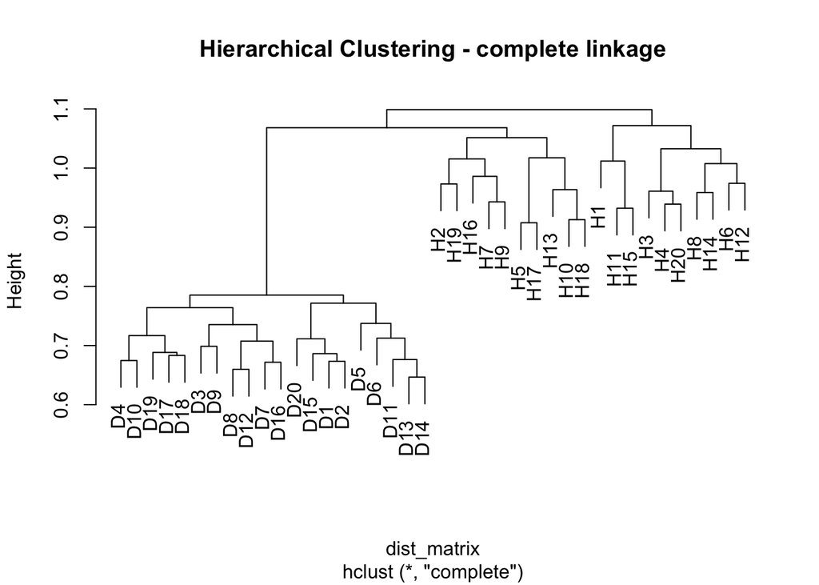

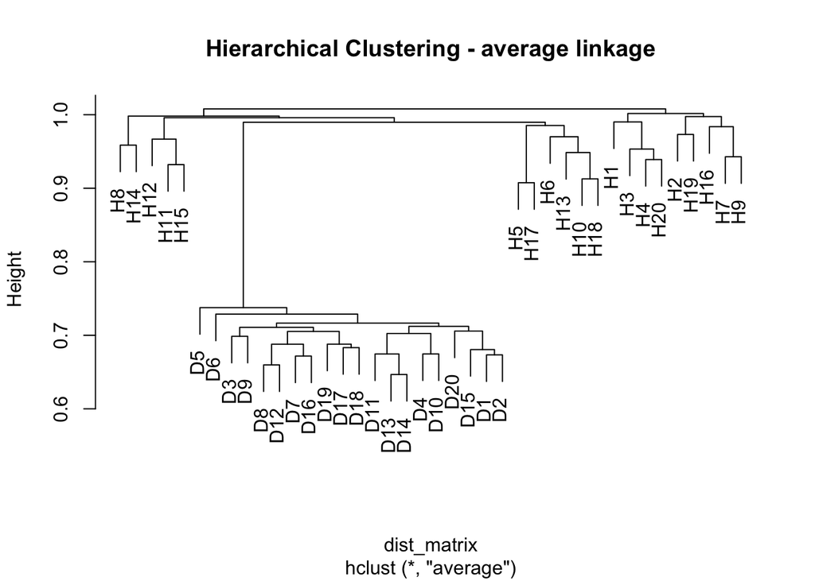

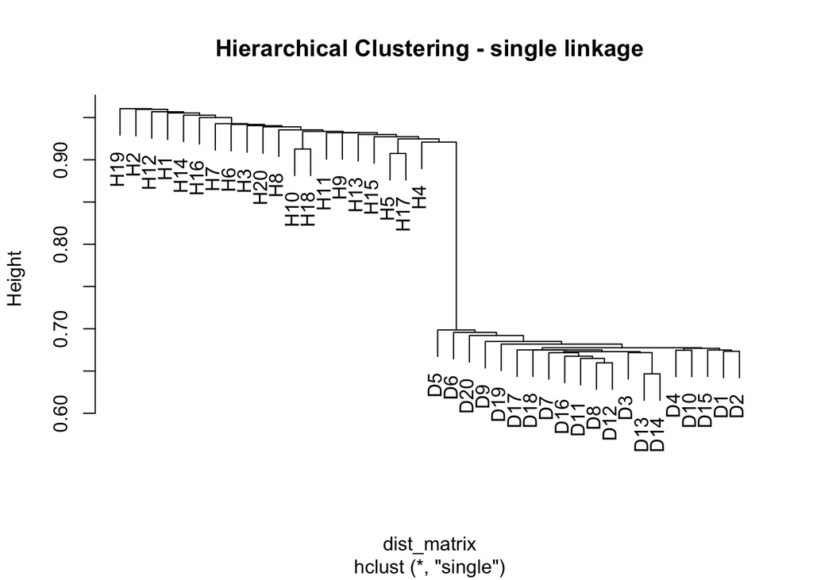

   ```r
   # Compute the correlation-based distance matrix
   cor_matrix <- cor(data)
   dist_matrix <- as.dist(1 - cor_matrix)

   # Perform hierarchical clustering with different linkage methods
   methods <- c("complete", "average", "single")
   for (method in methods) {
     hc <- hclust(dist_matrix, method = method)
     plot(hc, main = paste("Hierarchical Clustering -", method, "linkage"))
   }
   ```

### 2.2 PCA and UMAP (30 pts)

**Solution**

**Principal Component Analysis**

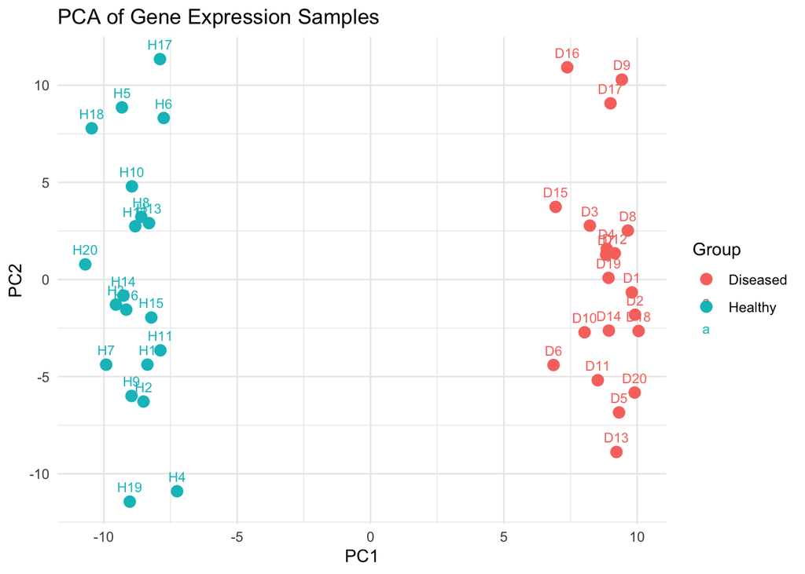

```r
# Transpose the data so that samples are rows and genes are columns
data_t <- t(data)

# Perform PCA on the transposed data
pca_results <- prcomp(data_t, center = TRUE, scale. = TRUE)

# Create a data frame for PCA results using the first two PCs
pca_df <- data.frame(
  PC1 = pca_results$x[, 1],
  PC2 = pca_results$x[, 2],
  Sample = rownames(pca_results$x)
)

# Assign sample groups based on sample names
pca_df$Group <- ifelse(grepl("^H", pca_df$Sample), "Healthy", "Diseased")

# Plot PCA results
pca_plot <- ggplot(pca_df, aes(x = PC1, y = PC2, color = Group, label = Sample)) +
  geom_point(size = 3) +
  geom_text(vjust = -1, hjust = 0.5, size = 3) +
  ggtitle("PCA of Gene Expression Samples") +
  theme_minimal()
print(pca_plot)
```

The PCA plot shows a clear separation between healthy and diseased samples along the first principal component (PC1), suggesting that the primary variance in gene expression is driven by disease status. This strong clustering indicates that the gene expression profiles of the two groups are distinct.

**Uniform Manifold Approximation and Projection**

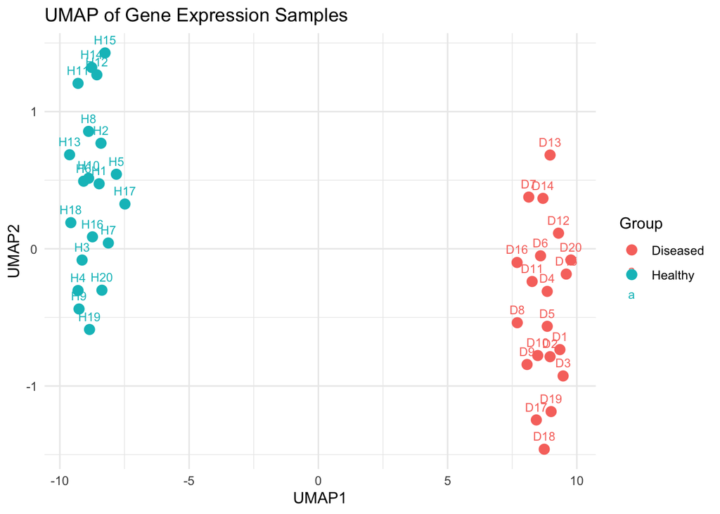

```r
# Perform UMAP analysis on the transposed data
umap_results <- umap(data_t)

# Extract the layout from the UMAP results which contains the embedding
umap_layout <- umap_results$layout

# Create a data frame for UMAP results using the first two UMAP dimensions
umap_df <- data.frame(
  UMAP1 = umap_layout[, 1],
  UMAP2 = umap_layout[, 2],
  Sample = rownames(data_t)
)

# Assign sample groups based on sample names
umap_df$Group <- ifelse(grepl("^H", umap_df$Sample), "Healthy", "Diseased")

# Plot UMAP results
umap_plot <- ggplot(umap_df, aes(x = UMAP1, y = UMAP2, color = Group, label = Sample)) +
  geom_point(size = 3) +
  geom_text(vjust = -1, hjust = 0.5, size = 3) +
  ggtitle("UMAP of Gene Expression Samples") +
  theme_minimal()
print(umap_plot)
```

The UMAP plot further reinforces the strong separation between healthy and diseased samples, with each group forming distinct clusters. Compared to PCA, UMAP shows even tighter grouping, suggesting that the differences in gene expression between the two groups are highly structured and separable in a nonlinear space. This indicates that gene expression patterns strongly differentiate the disease state, making classification models likely to perform well. If you need further statistical validation, techniques like clustering metrics or supervised classification could quantify this separation.

### 2.3 12.6.13 (c) (30 pts)

3. Your collaborator wants to know which genes differ the most across the two groups. Suggest a way to answer this question, and apply it here.

   **Solution**

   ```r
   # Create a factor variable
   class <- factor(rep(c("Healthy", "Diseased"), each = 20))

   # Perform a t-test
   pvals <- p.adjust(apply(data, 1, function(v) t.test(v ~ class)$p.value))

   significant_genes <- which(pvals < 0.05)
   print(significant_genes)
   ```

   ```
     [1]  11  12  13  14  15  16  17  18  19  20 501 502 503 504 505 506 507 508
    [19] 509 511 512 513 514 515 516 517 519 520 521 522 523 524 525 526 527 528
    [37] 529 530 531 532 533 534 535 536 537 538 539 540 541 542 543 544 545 546
    [55] 547 548 549 550 551 552 553 554 555 556 557 558 559 560 561 562 563 564
    [73] 565 566 567 568 569 570 571 572 574 575 576 577 578 579 580 581 582 583
    [91] 584 586 587 588 589 590 591 592 593 595 596 597 598 599 600
   ```